# EDA HS22 - Mini-Challenge: Hotelbuchungen

**Beginn: 15.11.2022, 08:15**

**Ende: 25.11.2022, 23:59**

**Abgabe: Pro Zweiergruppe ein .Rmd und .html File via e-mail an daniel.perruchoud@fhnw.ch**

**Vorname, Name:**

Noah, Recher

**Vorname, Name:**

Logan, Henchoz

**Erreichte Punktzahl:**

**Note:**

**Hiermit erklären wir, dass die vorliegende Arbeit selbständig und ohne Hilfe weiterer Personen erarbeitet und geschrieben wurde und auch nicht an andere Personen weitergereicht wurde und wird.**

# Einführung

## Beurteilungskriterien

Beurteilt werden Umfang, Inhalt und Form der Abgabe jeder Gruppe; die pro Aufgabe erworbenen Punktezahl bestimmt sich aus Vollständigkeit, Korrektheit der Analyse sowie Qualität der Codierung.

Die **maximale** Anzahl möglicher Punkte ist hinter jeder Aufgabe vermerkt.

Sprache: Empfohlen ist in den Codes, Grafiken und Tabellen konsistent Englisch zu verwenden, damit die Namen der Attribute nicht übersetzt werden müssen.

Visualisierung: Bitte achtet darauf, dass alle Grafiken übersichtlich und vollständig beschriftet und koloriert sind und die Art der verwendeten Grafik entsprechend dem Datentyp sinnvoll gewählt ist.

Dokumentation: Kommentiert eure Codes, wo spezielle Überlegung einfliessen und beschreibt die Resulate der Analysen in wenigen Sätzen präzise.

## Datenbeschreibung

Ihr erhaltet Daten von 40’060 Hotelbuchungen und den Auftrag diese zu analysieren. Pro Buchung stehen die folgenden 31 Attribute zur Verfügung (zusammengehörende Attribute werden gemeinsam beschrieben).

1. IsCanceled: Information, ob die Buchung storniert wurde,
2. LeadTime: Anzahl Tage zwischen Buchung und Eintreffen im Hotel,
3. ArrivalDateYear, -Month, -DateWeekNumber, DateDayOfMonth: Information zum Zeitpunkt des Eintreffens im Hotel,
4. StaysInWeekendNights, StaysInWeekNights: Anzahl gebuchter Nächte am Wochenende, bzw. an Werktagen,
5. Adults, Children, Babies: Anzahl Erwachsene, Kinder und Babies pro Buchung,
6. Meal: Art des gebuchten Verpflegungen, d.h. BB (Bed & Breakfast), HB (Half board oder Halbpension), FB (Full board oder Vollpension), Undefined (kein Paket),
7. Country: Herkunftsland des Gastes,
8. MarketSegment: Marktsegment der Buchung, wie z.B. Geschäftskunde, Direktkunde, Gruppe (TA = Tour Agents, TO = Tour Operators),
9. DistributionChannel: Vertriebskanal der Buchung (TA = Tour Agents, TO = Tour Operators),
10. IsRepeatedGuest: Information, ob die Buchung einem früheren Gast zugewiesen werden kann,
11. PreviousCancellations: Information zur Anzahl früherer Stornierungen des Gastes,
12. PreviousBookingsNotCanceled: Information zur Anzahl früherer Buchung des Gastes ohne Stornierung,
13. ReservedRoomType / AssignedRoomType: reservierter Zimmertyp, bzw. tatsächlich bezogener Zimmertyp,
14. BookingChanges: Anzahl Anpassungen der Buchung bis zum Check-In bzw. bis zur Stornierung,
15. DepositType: Art der bei Buchung hinterlegten Sicherheit. Non-Refundable bedeutet der Gesamtbetrag wurde bezahlt und kann nicht zurückgefordert werden, Refundable bedeutet ein Teilbetrag wurde bezahlt und kann zurückgefordert werden,
16. Agent / Company: Agentur bzw. Firma, welche die Buchung durchgeführt hat,
17. DaysInWaitingList: Anzahl Tage bis der Gast die Bestätigung für die Buchung erhalten hat,
18. CustomerType: Kundenart des Gastes,
19. ADR: Average Daily Rate in EURO, d.h. durchschnittlich bezahlter Preis pro Übernachtung
20. RequiredCarParkingSpaces: Anzahl für den Gast benötigter Parkplätze,
21. TotalOfSpecialRequests: Anzahl spezieller Anfragen des Gastes (z.B. Kinderbett, Doppelbett),
22. ReservationStatus: letzter Status der Buchung (Check-Out, No-Show, Canceled),
23. ReservationStatusDate: letzter Statusänderung der Buchung.

# Analysen vorbereiten

## Aufgabe (1 Punkt): Lade die Analyse-Pakete

Lade die für die Analysen relevanten Pakete.

Hinweis: Verwende für deine Implementierung `tidyverse`, für Zeitreihenanalyse `lubridate` und zusätzlich `ggmosaic` und `knitr`.

```r
library(tidyverse)
library(lubridate)
```

```r
library(ggmosaic)
library(knitr)
library(stringi)
```

# Daten laden und inspizieren

## Aufgabe (1 Punkt): Lade die Daten

Lade die zu analysierenden Daten.

Hinweis: Verwende für deine Implementierung die Funktion `read.csv()` und das File ‘H1.csv’.

```r
df_bookings_raw <- read.csv('./H1.csv')
```

## Aufgabe (1 Punkt): Untersuche die Grösse des Data Frames

Gib für die eingelesenen Daten die Anzahl Beobachtungen und Attribute aus.

```r
nrow(df_bookings_raw)
```

```
## [1] 40060
```

```r
ncol(df_bookings_raw)
```

```
## [1] 31
```

## Aufgabe (1 Punkt): Inspiziere die Dateninhalte

Gib eine Zufallsstichprobe von 5 Beobachtungen aus (verwende als Seed die Zahl 4711) und verschafffe dir einen Überblick über die Daten.

```r
set.seed(4711)
sample_n(df_bookings_raw, 5)
```

| IsCanceled | LeadTime | ArrivalDateYear | ArrivalDateMonth | ArrivalDateWeekNumber | ArrivalDateDayOfMonth | StaysInWeekendNights | StaysInWeekNights | Adults | Children | Babies | Meal | Country | MarketSegment | DistributionChannel | IsRepeatedGuest | PreviousCancellations | PreviousBookingsNotCanceled | ReservedRoomType | AssignedRoomType | BookingChanges | DepositType | Agent | Company | DaysInWaitingList | CustomerType | ADR | RequiredCarParkingSpaces | TotalOfSpecialRequests | ReservationStatus | … |
| --- | --- | --- | --- | --- | --- | --- | --- | --- | --- | --- | --- | --- | --- | --- | --- | --- | --- | --- | --- | --- | --- | --- | --- | --- | --- | --- | --- | --- | --- | --- |
| 0 | 388 | 2017 | May | 21 | 25 | 0 | 3 | 2 | 0 | 0 | BB | CN | Groups | TA/TO | 0 | 0 | 0 | E | E | 0 | No Deposit | 96 | NULL | 0 | Transient-Party | 72.00 | 0 | 1 | Check-Out | … |
| 1 | 328 | 2017 | June | 23 | 7 | 2 | 9 | 2 | 0 | 0 | BB | IRL | Online TA | TA/TO | 0 | 0 | 0 | A | A | 2 | No Deposit | 240 | NULL | 0 | Transient | 74.25 | 0 | 1 | Canceled | … |
| 1 | 96 | 2017 | March | 12 | 19 | 2 | 5 | 2 | 0 | 0 | BB | PRT | Groups | TA/TO | 0 | 0 | 0 | A | C | 1 | No Deposit | 177 | NULL | 0 | Transient-Party | 34.00 | 0 | 0 | Canceled | … |
| 1 | 32 | 2016 | April | 17 | 19 | 2 | 5 | 2 | 0 | 0 | HB | PRT | Groups | Direct | 0 | 0 | 0 | D | D | 0 | No Deposit | 273 | NULL | 0 | Transient-Party | 69.36 | 0 | 0 | Canceled | … |
| 0 | 152 | 2015 | July | 27 | 2 | 2 | 5 | 1 | 0 | 0 | HB | GBR | Offline TA/TO | TA/TO | 0 | 0 | 0 | A | A | 0 | No Deposit | 243 | NULL | 0 | Contract | 60.35 | 0 | 2 | Check-Out | … |

## Aufgabe (1 Punkt): Untersuche Struktur und Datentypen

Gib die Struktur des Data Frames aus und verschaffe dir einen Überblick über die Datentypen.

```r
str(df_bookings_raw)
```

```
## 'data.frame':    40060 obs. of  31 variables:
##  $ IsCanceled                 : int  0 0 0 0 0 0 0 0 1 1 ...
##  $ LeadTime                   : int  342 737 7 13 14 14 0 9 85 75 ...
##  $ ArrivalDateYear            : int  2015 2015 2015 2015 2015 2015 2015 2015 2015 2015 ...
##  $ ArrivalDateMonth           : chr  "July" "July" "July" "July" ...
##  $ ArrivalDateWeekNumber      : int  27 27 27 27 27 27 27 27 27 27 ...
##  $ ArrivalDateDayOfMonth      : int  1 1 1 1 1 1 1 1 1 1 ...
##  $ StaysInWeekendNights       : int  0 0 0 0 0 0 0 0 0 0 ...
##  $ StaysInWeekNights          : int  0 0 1 1 2 2 2 2 3 3 ...
##  $ Adults                     : int  2 2 1 1 2 2 2 2 2 2 ...
##  $ Children                   : int  0 0 0 0 0 0 0 0 0 0 ...
##  $ Babies                     : int  0 0 0 0 0 0 0 0 0 0 ...
##  $ Meal                       : chr  "BB       " "BB       " "BB       " "BB       " ...
##  $ Country                    : chr  "PRT" "PRT" "GBR" "GBR" ...
##  $ MarketSegment              : chr  "Direct" "Direct" "Direct" "Corporate" ...
```

[output cut: 17 more lines]

## Aufgabe (2 Punkte): Identifiziere Duplikate

Bestimme wieviele doppelte Beobachtungen im Data Frame auftauchen.

Hinweis: Aufgrund fehlender Hintergrundinformationen werden für die nächsten Schritte zunächst keine Beobachtungen entfernt, auch wenn im Datensatz viel redundante Informationen vorhanden sind!

```r
df_bookings_raw %>%
  filter(duplicated(df_bookings_raw)) %>%
  summarise(n_duplicates = n())
```

| n_duplicates |
| --- |
| 6092 |

## Aufgabe (10 Punkte): Identifiziere Gruppen doppelter Beobachtungen

Doppelte Beobachtungen treten im vorliegenden Datensatz in unterschiedlicher Gruppierung auf: es gibt Beobachtungen, die nur zweimal, aber auch Beobachtungen, die mehr als ein Dutzend mal vorhanden sind. Gib für die vier Gruppierungen mit den meisten doppelten Beobachtungen je eine vollständige Beobachtung aus.

Hinweis: Aufgrund fehlender Hintergrundinformationen werden für die nächsten Schritte zunächst keine Beobachtungen entfernt, auch wenn im Datensatz viel redundante Informationen vorhanden sind!

```r
df_bookings_raw %>%
  add_count(across(everything()), sort = TRUE, name = 'Number_of_duplicates') %>%
  distinct() %>%
  head(4)
```

|  | IsCanceled | LeadTime | ArrivalDateYear | ArrivalDateMonth | ArrivalDateWeekNumber | ArrivalDateDayOfMonth | StaysInWeekendNights | StaysInWeekNights | Adults | Children | Babies | Meal | Country | MarketSegment | DistributionChannel | IsRepeatedGuest | PreviousCancellations | PreviousBookingsNotCanceled | ReservedRoomType | AssignedRoomType | BookingChanges | DepositType | Agent | Company | DaysInWaitingList | CustomerType | ADR | RequiredCarParkingSpaces | TotalOfSpecialRequests | … |
| --- | --- | --- | --- | --- | --- | --- | --- | --- | --- | --- | --- | --- | --- | --- | --- | --- | --- | --- | --- | --- | --- | --- | --- | --- | --- | --- | --- | --- | --- | --- |
| 1 | 1 | 92 | 2016 | February | 9 | 26 | 1 | 2 | 2 | 0 | 0 | Undefined | PRT | Groups | TA/TO | 0 | 1 | 0 | A | A | 0 | Non Refund | 134 | NULL | 0 | Transient | 79.00 | 0 | 0 | … |
| 2 | 1 | 259 | 2015 | September | 38 | 17 | 0 | 3 | 2 | 0 | 0 | BB | GBR | Groups | Corporate | 0 | 1 | 0 | A | A | 0 | Non Refund | NULL | 223 | 0 | Transient | 40.05 | 0 | 0 | … |
| 3 | 1 | 106 | 2016 | March | 13 | 24 | 1 | 3 | 2 | 0 | 0 | FB | PRT | Groups | Direct | 0 | 0 | 0 | A | A | 0 | Non Refund | 68 | NULL | 0 | Transient | 84.00 | 0 | 0 | … |
| 4 | 1 | 259 | 2015 | September | 38 | 17 | 0 | 3 | 1 | 0 | 0 | BB | GBR | Groups | Corporate | 0 | 1 | 0 | A | A | 0 | Non Refund | NULL | 223 | 0 | Transient | 33.30 | 0 | 0 | … |

# Daten transformieren

## Aufgabe (2 Punkte): Benenne Attribute um

Die folgenden Attribute sind neu zu benennen (alterName -> neuerName)

- TotalOfSpecialRequests -> TotalSpecialRequests
- ADR -> AverageDailyRate
- IsCanceled -> BookingCancelled

```r
df_bookings <- df_bookings_raw %>%
  rename(
    TotalSpecialRequests = TotalOfSpecialRequests,
    AverageDailyRate = ADR,
    BookingCancelled = IsCanceled
  )
```

## Aufgabe (2 Punkte): Entferne Leerzeichen

Entferne *gleichzeitig für alle* character-wertigen Attribute, die Leerzeichen, welche vor oder nach dem Text auftauchen.

Hinweis: Verwende für deine Implementierung die Funktion `across()` und den Post [Umgang mit textuellen Daten mit tidyverse’s stringr](https://spaces.technik.fhnw.ch/spaces/explorative-datenanalyse/beitraege/umgang-mit-textuellen-daten-mit-tidyverses-stringr).

```r
df_bookings <- df_bookings %>%
  mutate(across(where(is.character), str_trim))
```

## Aufgabe (2 Punkte): Untersuche fehlende Informationen

Untersuche allfällige fehlende Informationen (NAs) im Data Frame und zähle wieviele NAs vorkommen.

```r
# Incomplete observations
df_bookings %>% filter(!complete.cases(.))
```

| BookingCancelled | LeadTime | ArrivalDateYear | ArrivalDateMonth | ArrivalDateWeekNumber | ArrivalDateDayOfMonth | StaysInWeekendNights | StaysInWeekNights | Adults | Children | Babies | Meal | Country | MarketSegment | DistributionChannel | IsRepeatedGuest | PreviousCancellations | PreviousBookingsNotCanceled | ReservedRoomType | AssignedRoomType | BookingChanges | DepositType | Agent | Company | DaysInWaitingList | CustomerType | AverageDailyRate | RequiredCarParkingSpaces | TotalSpecialRequests | ReservationStatus | … |
| --- | --- | --- | --- | --- | --- | --- | --- | --- | --- | --- | --- | --- | --- | --- | --- | --- | --- | --- | --- | --- | --- | --- | --- | --- | --- | --- | --- | --- | --- | --- |

```r
# Number of NAs
df_bookings %>%
  is.na() %>%
  sum()
```

```
## [1] 0
```

## Aufgabe (3 Punkte): Ersetze ‘NULL’ Werte

Ersetze *gleichzeitig alle* Werte ‘NULL’ für die Attribute ‘Company’ und ‘Agent’ durch `NA` und und zähle wieviele NAs in jedem der beiden Attributen vorkommen.

```r
df_bookings <- df_bookings %>%
  mutate(across(c('Company', 'Agent'), ~ na_if(., 'NULL')))

sum(is.na(df_bookings$Company))
```

```
## [1] 36952
```

```r
sum(is.na(df_bookings$Agent))
```

```
## [1] 8209
```

## Aufgabe (4 Punkte): Ersetze Abkürzungen

Ersetze *gleichzeitig* für die Attribute ‘MarketSegment’ und ‘DistributionChannel’ die Abkürzungen

- ‘TA’ durch ‘Tour Agent’,
- ‘TO’ durch ‘Tour Operator’.

Hinweis: Verwende für deine Implementierung die Funktion `gsub()` oder Ähnliches.

```r
df_bookings <- df_bookings %>%
  mutate_at(vars(c('MarketSegment', 'DistributionChannel')), ~ str_replace_all(., c('TO' = 'Tour Operator', 'TA' = 'Tour Agent')))
```

## Aufgabe (4 Punkte): Ersetze weitere Abkürzungen

Ersetze für das Attribut ‘Meal’ die verwendeten Abkürzungen

- ‘BB’ durch ‘Bed & Breakfast’,
- ‘HB’ durch ‘Half board’,
- ‘FB’ durch ‘Full board’,
- ‘Undefined’ durch ‘kein Paket’.

Ersetze weiter für die Attribute ‘BookingCancelled’ und ‘IsRepeatedGuest’ die Werte 1 durch ‘Yes’ und 0 durch ‘No’.

```r
df_bookings$Meal <- gsub(
  'BB', 'Bed & Breakfast',
  gsub(
    'HB', 'Half board',
    gsub(
      'FB', 'Full board',
      gsub('Undefined', 'kein Paket', df_bookings$Meal)
    )
  )
)

df_bookings <- df_bookings %>% mutate_at(vars(c('BookingCancelled', 'IsRepeatedGuest')), ~ str_replace_all(., c('1' = 'Yes', '0' = 'No')))
```

## Aufgabe (6 Punkte): Erstelle Datumsvariablen

Erstelle Datumsvariablen für Reservation und Ankunft aufgrund der Informationen ‘ReservationStatusDate’ bzw. ‘ArrivalDateYear’, ‘ArrivalDateYear’, ‘ArrivalDateDayOfMonth’.

Hinweis: Verwende für deine Implementierung die library `lubridate` und Informationen aus [R for Data Science, Chapter ‘Dates and times’](https://r4ds.had.co.nz/dates-and-times.html) sowie die Posts [Umgang mit Datumsinformationen](https://spaces.technik.fhnw.ch/spaces/explorative-datenanalyse/beitraege/umgang-mit-datumsinformationen) und [Umgang mit textuellen Daten mit tidyverse’s stringr](https://spaces.technik.fhnw.ch/spaces/explorative-datenanalyse/beitraege/umgang-mit-textuellen-daten-mit-tidyverses-stringr).

```r
df_bookings <- df_bookings %>%
  mutate(ArrivalDate = ymd(str_c(ArrivalDateYear, ArrivalDateMonth, ArrivalDateDayOfMonth, sep = '-')), ReservationStatusDate = ymd(ReservationStatusDate))
```

## Aufgabe (3 Punkte): Bilde Faktoren

Konvertiere sämtliche kategorialen Variablen und mache daraus Faktoren und überprüfe die Datentypen der konvertierten Variablen für die Variablen ‘BookingCancelled’ und ‘DepositType’.

Hinweis: Verwende für deine Implementierung `across()` und eine bestehende R Basis-Funktion zur Prüfung der erfolgreichen Bildung der Faktoren.

```r
df_bookings <- df_bookings %>%
  mutate(across(c('Agent', 'ArrivalDateMonth', 'AssignedRoomType', 'BookingCancelled', 'Company', 'Country', 'CustomerType', 'DepositType', 'DistributionChannel', 'IsRepeatedGuest', 'MarketSegment', 'Meal', 'ReservationStatus', 'ReservedRoomType'), as.factor))

typeof(df_bookings$BookingCancelled)
```

```
## [1] "integer"
```

```r
typeof(df_bookings$DepositType)
```

```
## [1] "integer"
```

## Aufgabe (7 Punkte): Erstelle neue Variablen

Erstelle neue Variablen, welche Auskunft geben über

- die Anzahl Logiernächte pro Buchung -> neue Variable ‘TotalNights’ als Summe der Anzahl Nächte an Wochentagen (‘StaysInWeekNights) und Wochenendtagen (’StaysInWeekendNights’),
- die Anzahl Personen pro Buchung -> neue Variable ‘GroupSize’ als Summe von ‘Adults’, ‘Children’ und ‘Babies’,
- den bezahlte Preis pro Aufenthalt -> neue Variable ‘Price’ gebildet als Produkt von ‘AverageDailyRate’ und ‘TotalNights’.

Erstelle daraus abgeleitet weitere Attribute für die Art des Aufenthalts (neue Faktor-Variable ‘StayType’):

- ‘Long stay’ definiert als Aufenthalt von mehr als 7 Nächten,
- ‘Full week’ definiert als Aufenthalt von 7 Nächten,
- ‘Week stay’ definiert als Aufenthalt von weniger als 7 Tagen ohne Wochenendübernachtungen,
- ‘Weeked only’ definiert als eintägiger Aufenthalt mit einer Wochenendübernachtung,
- ‘Long weekend’ definiert als zweitägiger Aufenthalt mit zwei Wochenendübernachtungen,

sowie den Haushaltstyp (neue Faktor-Variable ‘HouseholdType’):

- ‘Single’ definiert als Buchung für genau eine Erwachsene,
- ‘Couple’ definiert als Buchung für genau zwei Erwachsene,
- ‘Single Parent’ definiert als Buchung für eine Erwachsene und ein oder mehrere Kinder oder Babies,
- ‘Family’ definiert als Buchung für zwei Erwachsene und ein oder mehrere Kinder oder Babies,
- ‘Group’ definiert als Buchung für mehr als zwei Erwachsene (mit oder ohne Kinder / Babies),

```r
df_bookings <- df_bookings %>%
  mutate(TotalNights = StaysInWeekNights + StaysInWeekendNights, GroupSize = Adults + Children, Price = AverageDailyRate * TotalNights)

df_bookings <- df_bookings %>%
  mutate(StayType = case_when(
    TotalNights > 7 ~ 'Long stay',
    TotalNights == 7 ~ 'Full week',
    TotalNights < 7 & StaysInWeekendNights == 0 ~ 'Week stay',
    StaysInWeekendNights == 1 ~ 'Weekend only',
    StaysInWeekendNights == 2 ~ 'Long weekend'
  )) %>%
  mutate(StayType = as.factor(StayType))

df_bookings <- df_bookings %>%
  mutate(HouseholdType = case_when(
    Adults == 1 & Children == 0 & Babies == 0 ~ 'Single',
    Adults == 2 & Children == 0 & Babies == 0 ~ 'Couple',
    Adults == 1 & (Children > 0 | Babies > 0) ~ 'Single Parent',
    Adults == 2 & (Children > 0 | Babies > 0) ~ 'Family',
    Adults > 2 ~ 'Group'
  )) %>%
  mutate(HouseholdType = as.factor(HouseholdType))
```

# Summarische Statistiken erzeugen

## Aufgabe (3 Punkte): Erstelle Häufigkeitstabellen

Gib für die beiden oben bearbeiteten Attribute ‘MarketSegment’ und ‘DistributionChannel’ je eine separate Häufigkeitstabelle aus.

Hinweis: Verwende für deine Implementierung nur **einen** Aufruf der Funktion `summary()`.

```r
summary(df_bookings[c('MarketSegment', 'DistributionChannel')])
```

```
##                           MarketSegment                 DistributionChannel
##  Complementary                   :  201   Corporate               : 3269
##  Corporate                       : 2309   Direct                  : 7865
##  Direct                          : 6513   Tour Agent/Tour Operator:28925
##  Groups                          : 5836   Undefined               :    1
##  Offline Tour Agent/Tour Operator: 7472
##  Online Tour Agent               :17729
```

## Aufgabe (3 Punkte): Erstelle weitere Häufigkeitstabellen

Gib für die Attribute ‘Meal’ und ‘IsRepeatedGuest’ separat tabellarische Häufigkeitsverteilungen aus.

Hinweis: Verwende für deine Implementierung die Funktion `kable()`.

```r
kable(proportions(summary(df_bookings$Meal)), caption = 'Meal', digits = 3, col.names = 'Frequency')
```

Meal

|  | Frequency |
| --- | --- |
| Bed & Breakfast | 0.749 |
| Full board | 0.019 |
| Half board | 0.201 |
| kein Paket | 0.029 |
| SC | 0.002 |

```r
kable(proportions(summary(df_bookings$IsRepeatedGuest)), caption = 'IsRepeatedGuest', digits = 3, col.names = 'Frequency')
```

IsRepeatedGuest

|  | Frequency |
| --- | --- |
| No | 0.956 |
| Yes | 0.044 |

## Aufgabe (5 Punkte): Erstelle weitere Häufigkeitstabellen

Erstelle eine summarische, univariate Statistik für alle Attribute und dokumentiere kurz allfällige Besonderheiten.

```r
summary(df_bookings)
```

```
##  BookingCancelled    LeadTime      ArrivalDateYear ArrivalDateMonth
##  No :28938        Min.   :  0.00   Min.   :2015    August : 4894
##  Yes:11122        1st Qu.: 10.00   1st Qu.:2016    July   : 4573
##                   Median : 57.00   Median :2016    April  : 3609
##                   Mean   : 92.68   Mean   :2016    May    : 3559
##                   3rd Qu.:155.00   3rd Qu.:2017    October: 3555
##                   Max.   :737.00   Max.   :2017    March  : 3336
##                                                    (Other):16534
##  ArrivalDateWeekNumber ArrivalDateDayOfMonth StaysInWeekendNights
##  Min.   : 1.00         Min.   : 1.00         Min.   : 0.00
##  1st Qu.:16.00         1st Qu.: 8.00         1st Qu.: 0.00
##  Median :28.00         Median :16.00         Median : 1.00
##  Mean   :27.14         Mean   :15.82         Mean   : 1.19
##  3rd Qu.:38.00         3rd Qu.:24.00         3rd Qu.: 2.00
##  Max.   :53.00         Max.   :31.00         Max.   :19.00
##
##  StaysInWeekNights     Adults          Children           Babies
##  Min.   : 0.000    Min.   : 0.000   Min.   : 0.0000   Min.   :0.0000
##  1st Qu.: 1.000    1st Qu.: 2.000   1st Qu.: 0.0000   1st Qu.:0.0000
##  Median : 3.000    Median : 2.000   Median : 0.0000   Median :0.0000
##  Mean   : 3.129    Mean   : 1.867   Mean   : 0.1287   Mean   :0.0139
##  3rd Qu.: 5.000    3rd Qu.: 2.000   3rd Qu.: 0.0000   3rd Qu.:0.0000
##  Max.   :50.000    Max.   :55.000   Max.   :10.0000   Max.   :2.0000
##
##               Meal          Country
##  Bed & Breakfast:30005   PRT    :17630
##  Full board     :  754   GBR    : 6814
##  Half board     : 8046   ESP    : 3957
##  kein Paket     : 1169   IRL    : 2166
##  SC             :   86   FRA    : 1611
##                          DEU    : 1203
##                          (Other): 6679
##                           MarketSegment                 DistributionChannel
##  Complementary                   :  201   Corporate               : 3269
##  Corporate                       : 2309   Direct                  : 7865
##  Direct                          : 6513   Tour Agent/Tour Operator:28925
##  Groups                          : 5836   Undefined               :    1
##  Offline Tour Agent/Tour Operator: 7472
##  Online Tour Agent               :17729
##
```

[output cut: 33 more lines]

```
##  Canceled :10831   Min.   :2014-11-18    Min.   :2015-07-01   Min.   : 0.000
##  Check-Out:28938   1st Qu.:2016-01-26    1st Qu.:2016-02-14   1st Qu.: 2.000
##  No-Show  :  291   Median :2016-07-31    Median :2016-08-19   Median : 3.000
##                    Mean   :2016-07-28    Mean   :2016-08-15   Mean   : 4.319
##                    3rd Qu.:2017-02-11    3rd Qu.:2017-03-05   3rd Qu.: 7.000
##                    Max.   :2017-09-14    Max.   :2017-08-31   Max.   :69.000
##
##    GroupSize          Price                StayType           HouseholdType
##  Min.   : 0.000   Min.   : -63.8   Full week   : 6596   Couple       :28034
##  1st Qu.: 2.000   1st Qu.: 117.0   Long stay   : 4009   Family       : 3391
##  Median : 2.000   Median : 273.0   Long weekend: 6082   Group        : 1474
##  Mean   : 1.996   Mean   : 435.4   Week stay   :14181   Single       : 7013
##  3rd Qu.: 2.000   3rd Qu.: 593.0   Weekend only: 9192   Single Parent:  135
##  Max.   :55.000   Max.   :7590.0                        NA's         :   13
##
```

### Observations

ArrivalDateMonth: Most guests arrive in the Summer months August and July.

Adults: Q1, Q3 and Median = 2. Most customers visit in pairs.

Children: Most customers have no children.

Babies: Most customers have no babies.

Meal: Bed & Breakfast is booked the most. SC unknown value.

Country: Most customers come from western countries with most of them coming from PRT.

DistributionChannel: One undefined value.

IsRepeatedGuest: Most customers are visiting for the first time.

PreviousCancellations / PreviousBookingsNotCanceled: Q1, Q2, Median = 0. Almost no previous cancellations.

ReservedRoomType / AssignedRoomType: Most of the customers book RoomType A. However RoomType A is also the only Room that gets assigned less than it gets reserved.

Agent / Company: NA values.

GroupSize: Q1, Q2, Median = 2. Most customers are couples.

Price: Minimum value is negative.

StayType: Most customers stay during the week.

HouseholdType: Most customers are couples which is confirmed by GroupSize. There are 13 NAs.

## Aufgabe (4 Punkte): Prüfe Auffälligkeiten

Erstelle eine tabellarische Häufigkeitsverteilung für das neu gebildete Attribut ‘HouseholdType’ und untersuche und beschreibe Auffälligkeiten.

Hinweis: Verwende für deine Implementierung die Funktion `kable()`.

```r
kable(proportions(summary(df_bookings$HouseholdType)), caption = 'HouseholdType', digits = 5, col.names = '%')
```

HouseholdType

|  | % |
| --- | --- |
| Couple | 0.69980 |
| Family | 0.08465 |
| Group | 0.03679 |
| Single | 0.17506 |
| Single Parent | 0.00337 |
| NA’s | 0.00032 |

```r
df_bookings %>% filter(is.na(HouseholdType))
```

| BookingCancelled | LeadTime | ArrivalDateYear | ArrivalDateMonth | ArrivalDateWeekNumber | ArrivalDateDayOfMonth | StaysInWeekendNights | StaysInWeekNights | Adults | Children | Babies | Meal | Country | MarketSegment | DistributionChannel | IsRepeatedGuest | PreviousCancellations | PreviousBookingsNotCanceled | ReservedRoomType | AssignedRoomType | BookingChanges | DepositType | Agent | Company | DaysInWaitingList | CustomerType | AverageDailyRate | RequiredCarParkingSpaces | TotalSpecialRequests | ReservationStatus | … |
| --- | --- | --- | --- | --- | --- | --- | --- | --- | --- | --- | --- | --- | --- | --- | --- | --- | --- | --- | --- | --- | --- | --- | --- | --- | --- | --- | --- | --- | --- | --- |
| No | 1 | 2015 | October | 41 | 6 | 0 | 3 | 0 | 0 | 0 | SC | PRT | Corporate | Corporate | No | 0 | 0 | A | I | 1 | No Deposit | NA | 174 | 0 | Transient-Party | 0 | 0 | 0 | Check-Out | … |
| No | 0 | 2015 | October | 42 | 12 | 0 | 0 | 0 | 0 | 0 | SC | PRT | Corporate | Corporate | No | 0 | 0 | A | I | 0 | No Deposit | NA | 174 | 0 | Transient | 0 | 0 | 0 | Check-Out | … |
| No | 36 | 2015 | November | 47 | 20 | 1 | 2 | 0 | 0 | 0 | SC | ESP | Groups | Tour Agent/Tour Operator | No | 0 | 0 | A | C | 0 | No Deposit | 38 | NA | 0 | Transient-Party | 0 | 0 | 0 | Check-Out | … |
| No | 165 | 2015 | December | 53 | 30 | 1 | 4 | 0 | 0 | 0 | SC | PRT | Groups | Tour Agent/Tour Operator | No | 0 | 0 | A | A | 1 | No Deposit | 308 | NA | 122 | Transient-Party | 0 | 0 | 0 | Check-Out | … |
| No | 165 | 2015 | December | 53 | 30 | 2 | 4 | 0 | 0 | 0 | SC | PRT | Groups | Tour Agent/Tour Operator | No | 0 | 0 | A | C | 1 | No Deposit | 308 | NA | 122 | Transient-Party | 0 | 0 | 0 | Check-Out | … |
| Yes | 0 | 2016 | February | 8 | 15 | 0 | 0 | 0 | 0 | 0 | SC | NULL | Offline Tour Agent/Tour Operator | Tour Agent/Tour Operator | No | 0 | 0 | P | P | 0 | No Deposit | NA | 383 | 0 | Transient | 0 | 0 | 0 | Canceled | … |
| Yes | 0 | 2016 | November | 48 | 21 | 0 | 0 | 0 | 0 | 0 | SC | NULL | Offline Tour Agent/Tour Operator | Tour Agent/Tour Operator | No | 0 | 0 | P | P | 0 | No Deposit | NA | 386 | 0 | Group | 0 | 0 | 0 | Canceled | … |
| No | 31 | 2016 | December | 53 | 27 | 2 | 8 | 0 | 0 | 0 | Bed & Breakfast | PRT | Direct | Direct | No | 0 | 0 | D | D | 3 | No Deposit | NA | NA | 0 | Transient | 28 | 1 | 0 | Check-Out | … |
| No | 4 | 2017 | January | 2 | 14 | 0 | 1 | 0 | 0 | 0 | SC | PRT | Groups | Tour Agent/Tour Operator | No | 0 | 0 | A | G | 0 | No Deposit | 168 | NA | 0 | Transient-Party | 0 | 0 | 0 | Check-Out | … |
| No | 46 | 2017 | January | 4 | 25 | 3 | 9 | 0 | 0 | 0 | SC | FRA | Direct | Direct | No | 0 | 0 | A | I | 8 | No Deposit | NA | NA | 0 | Transient | 0 | 0 | 0 | Check-Out | … |

[output cut: 3 more lines]

### Observations

In total there are 13 NAs. By filtering the column for NAs, we can see that adults, children and babies is set to zero. The reason for this is unkown, but it is probably missing data. We can also say, that over 2/3 of the guests are couples.

## Aufgabe (3 Punkte): Prüfe weitere Auffälligkeiten

Erstelle eine Statistik für das Attribut ‘AverageDailyRate’ und identifiziere Auffälligkeiten.

```r
summary(df_bookings$AverageDailyRate)
```

```
##    Min. 1st Qu.  Median    Mean 3rd Qu.    Max.
##   -6.38   50.00   75.00   94.95  125.00  508.00
```

```r
df_bookings %>% filter(AverageDailyRate < 0)
```

| BookingCancelled | LeadTime | ArrivalDateYear | ArrivalDateMonth | ArrivalDateWeekNumber | ArrivalDateDayOfMonth | StaysInWeekendNights | StaysInWeekNights | Adults | Children | Babies | Meal | Country | MarketSegment | DistributionChannel | IsRepeatedGuest | PreviousCancellations | PreviousBookingsNotCanceled | ReservedRoomType | AssignedRoomType | BookingChanges | DepositType | Agent | Company | DaysInWaitingList | CustomerType | AverageDailyRate | RequiredCarParkingSpaces | TotalSpecialRequests | ReservationStatus | … |
| --- | --- | --- | --- | --- | --- | --- | --- | --- | --- | --- | --- | --- | --- | --- | --- | --- | --- | --- | --- | --- | --- | --- | --- | --- | --- | --- | --- | --- | --- | --- |
| No | 195 | 2017 | March | 10 | 5 | 4 | 6 | 2 | 0 | 0 | Bed & Breakfast | GBR | Groups | Direct | Yes | 0 | 2 | A | H | 2 | No Deposit | 273 | NA | 0 | Transient-Party | -6.38 | 0 | 0 | Check-Out | … |

```r
df_bookings %>% filter(AverageDailyRate == 0)
```

| BookingCancelled | LeadTime | ArrivalDateYear | ArrivalDateMonth | ArrivalDateWeekNumber | ArrivalDateDayOfMonth | StaysInWeekendNights | StaysInWeekNights | Adults | Children | Babies | Meal | Country | MarketSegment | DistributionChannel | IsRepeatedGuest | PreviousCancellations | PreviousBookingsNotCanceled | ReservedRoomType | AssignedRoomType | BookingChanges | DepositType | Agent | Company | DaysInWaitingList | CustomerType | AverageDailyRate | RequiredCarParkingSpaces | TotalSpecialRequests | ReservationStatus | … |
| --- | --- | --- | --- | --- | --- | --- | --- | --- | --- | --- | --- | --- | --- | --- | --- | --- | --- | --- | --- | --- | --- | --- | --- | --- | --- | --- | --- | --- | --- | --- |
| No | 342 | 2015 | July | 27 | 1 | 0 | 0 | 2 | 0 | 0 | Bed & Breakfast | PRT | Direct | Direct | No | 0 | 0 | C | C | 3 | No Deposit | NA | NA | 0 | Transient | 0 | 0 | 0 | Check-Out | … |
| No | 737 | 2015 | July | 27 | 1 | 0 | 0 | 2 | 0 | 0 | Bed & Breakfast | PRT | Direct | Direct | No | 0 | 0 | C | C | 4 | No Deposit | NA | NA | 0 | Transient | 0 | 0 | 0 | Check-Out | … |
| No | 32 | 2015 | July | 27 | 4 | 0 | 1 | 4 | 0 | 0 | Full board | PRT | Complementary | Direct | No | 0 | 0 | H | H | 2 | No Deposit | NA | NA | 0 | Transient | 0 | 0 | 1 | Check-Out | … |
| No | 111 | 2015 | July | 28 | 6 | 0 | 0 | 2 | 0 | 0 | Bed & Breakfast | PRT | Online Tour Agent | Tour Agent/Tour Operator | No | 0 | 0 | A | H | 0 | No Deposit | 240 | NA | 0 | Transient | 0 | 0 | 2 | Check-Out | … |
| No | 0 | 2015 | July | 28 | 6 | 0 | 0 | 1 | 0 | 0 | Bed & Breakfast | PRT | Direct | Direct | No | 0 | 0 | E | H | 0 | No Deposit | 250 | NA | 0 | Transient | 0 | 0 | 0 | Check-Out | … |
| No | 8 | 2015 | July | 28 | 7 | 0 | 0 | 2 | 0 | 0 | Bed & Breakfast | PRT | Direct | Direct | No | 0 | 0 | A | A | 0 | No Deposit | NA | NA | 0 | Transient | 0 | 0 | 1 | Check-Out | … |
| No | 8 | 2015 | July | 28 | 7 | 0 | 0 | 2 | 0 | 0 | Bed & Breakfast | PRT | Online Tour Agent | Tour Agent/Tour Operator | No | 0 | 0 | A | E | 0 | No Deposit | 240 | NA | 0 | Transient | 0 | 0 | 1 | Check-Out | … |
| Yes | 57 | 2015 | July | 29 | 15 | 0 | 2 | 2 | 0 | 0 | Full board | PRT | Groups | Direct | No | 0 | 0 | A | A | 0 | No Deposit | 305 | NA | 0 | Transient-Party | 0 | 0 | 0 | Canceled | … |
| No | 57 | 2015 | July | 29 | 15 | 0 | 2 | 1 | 0 | 0 | Full board | PRT | Groups | Direct | No | 0 | 0 | A | A | 1 | No Deposit | 305 | NA | 0 | Transient-Party | 0 | 0 | 0 | Check-Out | … |
| No | 6 | 2015 | July | 29 | 17 | 0 | 0 | 2 | 0 | 0 | Bed & Breakfast | PRT | Online Tour Agent | Tour Agent/Tour Operator | No | 0 | 0 | A | A | 0 | No Deposit | 240 | NA | 0 | Transient | 0 | 0 | 1 | Check-Out | … |

[output cut: 741 more lines]

### Observations

First we saw, that there is an observation with a negative value, which is invalid because it is not possible that customers pay a negative price for the hotel. There are also observation with an average daily rate of 0.

## Aufgabe (2 Punkte): Erstelle einen bereinigten Datensatz

Bereinige das Data Frame, indem du Beobachtungen mit Auffälligkeiten und unplausiblen Werten in den Attributen ‘AverageDailyRate’ und ‘HouseholdType’ entfernst.

**FÜR ALLE WEITEREN ANALYSEN IST AUSSCHLIESSLICH DER BEREINIGTE DATENSATZ ZU VERWENDEN!!!**

```r
df_bookings <- df_bookings %>%
  subset(AverageDailyRate > 0) %>%
  drop_na(HouseholdType)
```

# Visualisierung

**FÜR ALLE WEITEREN ANALYSEN IST AUSSCHLIESSLICH DER BEREINIGTE DATENSATZ ZU VERWENDEN!!!**

## Aufgabe (5 Punkte): Analysiere Zusammenhänge kategorialer Grössen

Erstelle eine graphische Analyse, welche die relativen Unterschiede des Auftretens von Spezialwünschen (s. ‘TotalSpecialRequests’) bei Hotelreservationen nach Haushaltstyp (s. ‘HouseholdType’) untersucht und zusätzlich betrachtet, ob die Buchung storniert wurde oder nicht (s. ‘BookingCancelled’).

Hinweis: Verwende für deine Implementierung die Funktion `facet_wrap(, labeller = ...)`.

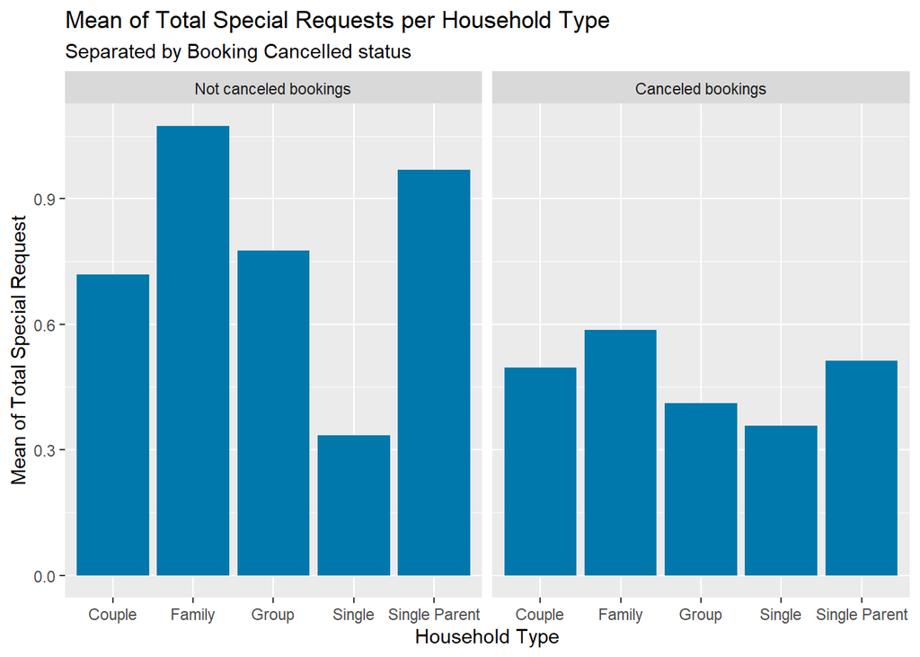

```r
df_bookings %>%
  ggplot(aes(HouseholdType, TotalSpecialRequests)) +
  stat_summary(fun = 'mean', geom = 'bar', fill = '#0078ab') +
  facet_wrap(~ BookingCancelled, ncol = 2, labeller = labeller(
    BookingCancelled =
      c(
        'No' = 'Not canceled bookings',
        'Yes' = 'Canceled bookings'
      )
  )) +
  labs(title = 'Mean of Total Special Requests per Household Type', subtitle = 'Separated by Booking Cancelled status', x = 'Household Type', y = 'Mean of Total Special Request') +
  theme(legend.position = 'none')
```

## Aufgabe (5 Punkte): Erstelle eine visuelle Häufigkeitstabelle

Erstelle eine Heatmap, welche das Vorkommen von Art des Aufenthalts und Haushaltstyp farblich und in Zahlen darstellt.

Hinweis: Verwende für deine Implementierung die Funktion `geom_tile()` und eine Farbskala, welche grosse Häufigkeiten dunkler einfärbt als kleine.

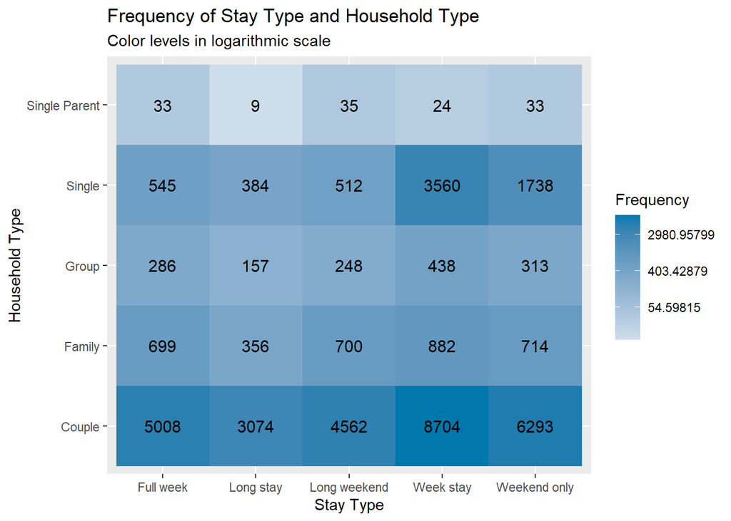

```r
df_bookings %>%
  group_by(StayType, HouseholdType) %>%
  summarize(Frequency = n()) %>%
  ggplot(aes(StayType, HouseholdType, fill = Frequency)) +
  geom_tile() +
  geom_text(aes(label = Frequency), size = 4) +
  scale_fill_gradient2(trans = 'log', high = '#0078ab') +
  labs(title = 'Frequency of Stay Type and Household Type', subtitle = 'Color levels in logarithmic scale', x = 'Stay Type', y = 'Household Type')
```

## Aufgabe (5 Punkte): Erstelle einen Mosaic-Plots

Erstelle analog zur Heatmap oben einen Mosaicplot, welcher das Vorkommen von Art des Aufenthalts und Haushaltstyp darstellt (Farben können frei gewählt werden, Zahlen sind nicht im Plot zu integrieren).

Hinweis: Verwende für deine Implementierung die Funktion `geom_mosaic()` aus dem Paket `ggmosaic`.

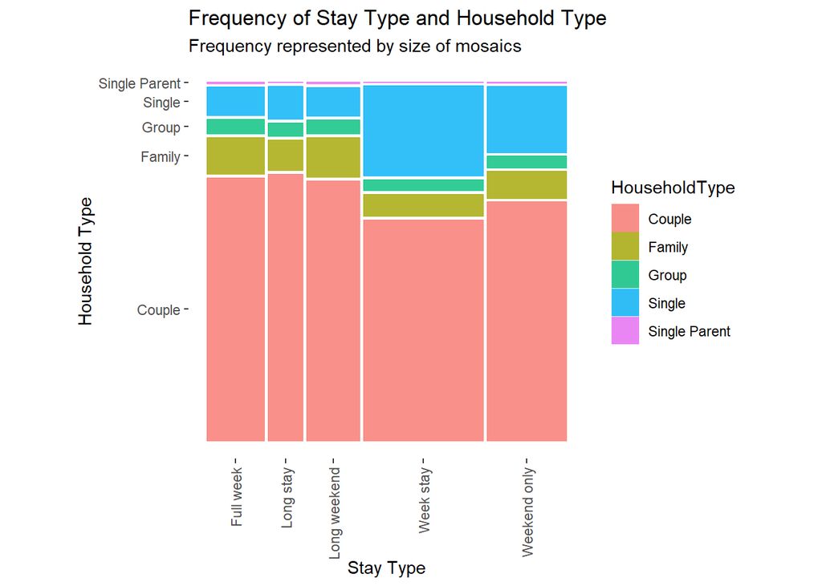

```r
ggplot(df_bookings) +
  geom_mosaic(aes(x = product(StayType), fill = HouseholdType)) +
  theme_mosaic() +
  theme(axis.text.x = element_text(angle = 90, hjust = 1, vjust = .5)) +
  labs(title = 'Frequency of Stay Type and Household Type', subtitle = 'Frequency represented by size of mosaics', x = 'Stay Type', y = 'Household Type')
```

## Aufgabe (10 Punkte): Analysiere die Definition des Tagesdurchschnittpreises

Plausibilisiere visuell, dass die Angaben des Attributs Tagesdurchschnittpreis (‘AverageDailyRate’) sich nicht auf den Preis pro Übernachtung und Person, sondern auf den Preis pro Übernachtung pro Zimmer beziehen.

Hinweis: Die Visualisierung ist kein abschliessender Beweis. Beschreibe klar und nachvollziehbar, wieso die von dir gezeigte Grafik ein Indiz dafür ist, dass sich die gelisteten Tagesdurchschnittpreise auf Übernachtungen pro Zimmer beziehen.

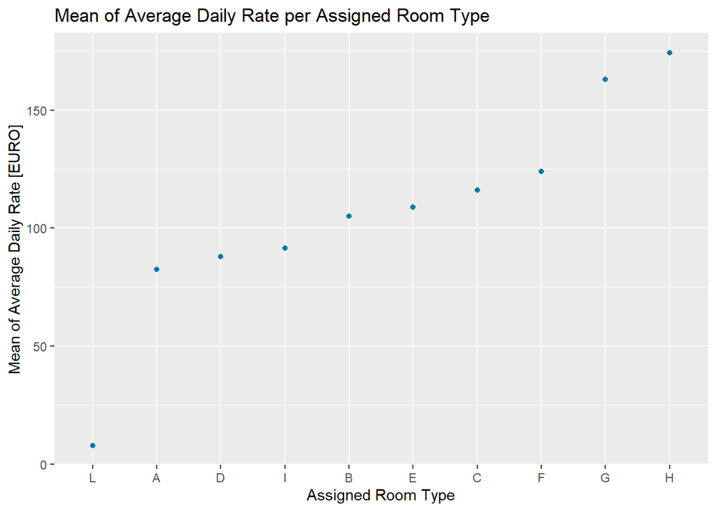

```r
df_bookings %>%
  ggplot(aes(reorder(AssignedRoomType, AverageDailyRate), AverageDailyRate)) +
  stat_summary(fun = 'mean', geom = 'point', color = '#0078ab') +
  labs(title = 'Mean of Average Daily Rate per Assigned Room Type', x = 'Assigned Room Type', y = 'Mean of Average Daily Rate [EURO]')
```

#### Observation:

In the plot we can see that there is a correlation between the Room Type and AverageDailyRate. The rooms seem to be rented out at different prices. The alphabetical order seems not to be of any relevance regarding the AverageDailyRate. For this we have to ignore the alphabetical order.

## Aufgabe (10 Punkte): Plausibilisiere Interpretation des Tagesdurchschnittpreises

Identifiziere drei Fälle, welche illustrieren, dass die Angaben des Attributs Tagesdurchschnittpreis (‘AverageDailyRate’) sich auf den Preis pro Übernachtung pro Zimmer beziehen, indem du gezielt paarweise Buchungen vergleichst, wo sich Anzahl Personen und Tagesdurchschnittpreis unterscheiden, andere relevante Variablen aber übereinstimmen.

Gib für diese drei Fälle folgende Attribute aus: ‘GroupSize.x’, ‘GroupSize.y’, ‘AverageDailyRate.x’, ‘AverageDailyRate.y’ (die Endung ‘.x’ bezieht sich auf das Attribut der ersten, ‘.y’ der zweiten Beobachtung der paarweisen Buchung).

Hinweis: Exploriere Beispiele von Hand und mache dann ein Refactoring deines Codes, d.h. verwende für deine Implementierung eine eigene Funktion mit `{{}}`, so dass eine wählbare Menge zufälliger Beispiele selektiert werden kann.

```r
picker <- function(amount) {
  sample <- df_bookings[sample(nrow(df_bookings), {{amount}}),] #select the amount of samples required
  df_out <- NULL                                                #by (amount)

  for (i in c(1:nrow(sample))) {                                #iterate through all samples and search
    sample_filtered <- df_bookings %>%                          #for matching ones
      filter(GroupSize != as.integer(sample[i,]['GroupSize'])) %>% #filter important feature required
      filter(AverageDailyRate != as.double(sample[i,]['AverageDailyRate'])) %>%
      filter(TotalNights == as.integer(sample[i,]['TotalNights'])) %>%
      filter(AssignedRoomType == sample[i,20]) %>%
      filter(BookingCancelled == sample[i,1]) %>%
      filter(ArrivalDate != sample[i,32]) %>%
      filter(TotalSpecialRequests == sample[i,29])

    sample_filtered <- sample_filtered[sample(nrow(sample_filtered), 1),] #from rows that match sample
    sample$Pair <- i                                                      #requirements, select one random
    sample_filtered$Pair <- i

    if (nrow(sample_filtered) == 0) {       #this is in case that we don't find matching, then we
      temp <- picker(1)                     #relaunch the function recursively and search for new sample
      sample_filtered <- temp[2,]           #and match
      sample[i,] <- temp[1,]
    }

    df_temp <- NULL

    df_temp <- df_temp %>%                  #this is for formatting the df to the required format
      cbind(sample[i,34]) %>%
      cbind(sample_filtered[1,34]) %>%
      cbind(sample[i,27]) %>%
      cbind(sample_filtered[1,27])

    df_out <- df_out %>%
        rbind(df_temp)
  }

  df_out <- as.data.frame(df_out)

  df_out <- df_out %>%
    rename(
      'GroupSize.x' = 'V1',
      'GroupSize.y' = 'V2',
      'AverageDailyRate.x' = 'V3',
      'AverageDailyRate.y' = 'V4'
      )

  print(df_out)
}

picker(3)
```

```
##   GroupSize.x GroupSize.y AverageDailyRate.x AverageDailyRate.y
## 1           2           1              58.00              33.30
## 2           2           1              37.54              50.40
## 3           2           1              55.87              76.86
```

### Observations

In one sample we had the following data:

| GroupSize.x | GroupSize.y | AverageDailyRate.x | AverageDailyRate.y |
| --- | --- | --- | --- |
| 2 | 1 | 112.7 | 81.6 |
| 2 | 1 | 48.0 | 43.0 |
| 4 | 3 | 94.0 | 162.0 |

You can clearly see that the GroupSize is not related to the AverageDailyRate.

## Aufgabe (5 Punkte): Erstelle Facet-Plot des Tagesdurchschnittpreises

Reproduziere die folgende Grafik (‘Figure 1: AverageDailyRate_2016_RoomA’) für die Verteilung der monatlichen Tagesdurchschnittpreise (‘AverageDailyRate’) von Zimmern mit AssignedRoomType ‘A’ für das Jahr 2016 mit allen gezeigten Details.

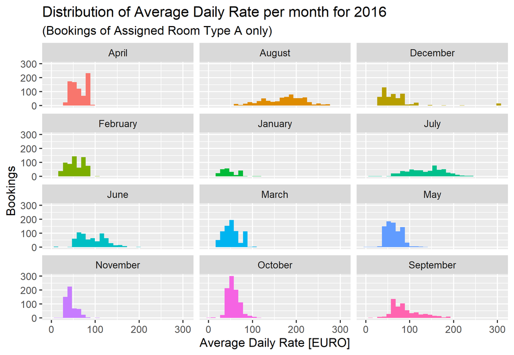

AverageDailyRate_2016_RoomA

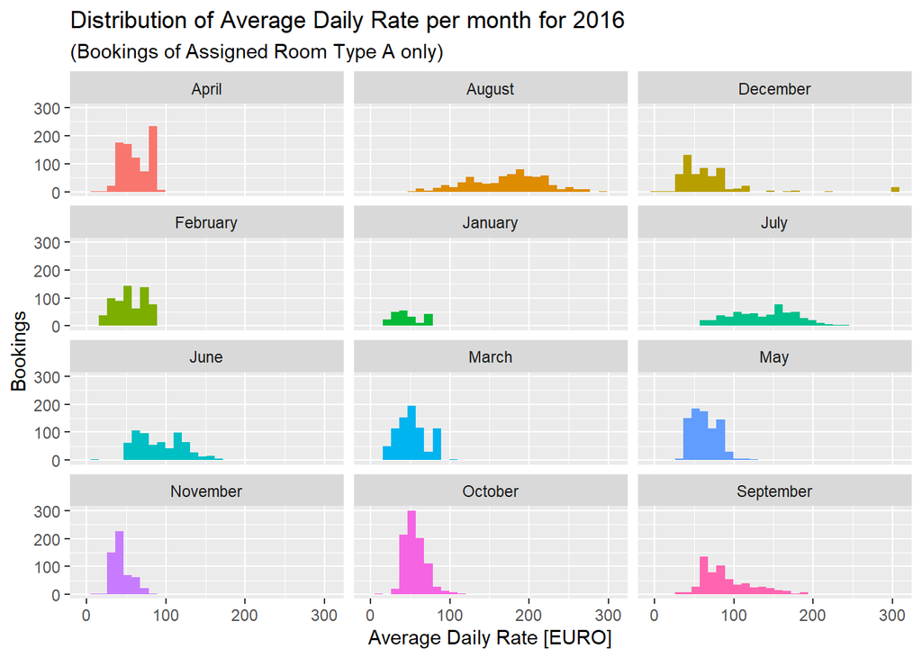

```r
df_bookings %>%
  filter(ArrivalDateYear == 2016 & AssignedRoomType == 'A') %>%
  ggplot(aes(AverageDailyRate)) +
  geom_histogram(aes(fill = ArrivalDateMonth)) +
  facet_wrap(~ ArrivalDateMonth, ncol = 3) +
  theme(legend.position = 'none') +
  labs(title = 'Distribution of Average Daily Rate per month for 2016', subtitle = '(Bookings of Assigned Room Type A only)', x = 'Average Daily Rate [EURO]', y = 'Bookings')
```

## Aufgabe (5 Punkte): Verbessere Facet-Plot des Tagesdurchschnittpreises

Verbessere die vorangehende Grafik so, dass die Reihenfolge der Monate chronologisch geordnet ist.

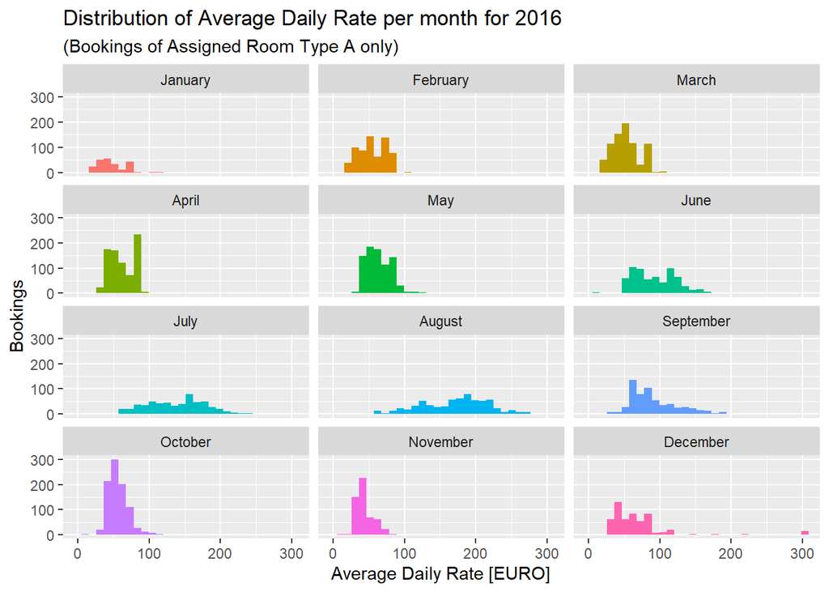

```r
df_bookings$ArrivalDateMonth <- factor(df_bookings$ArrivalDateMonth, levels = c('January', 'February', 'March', 'April', 'May', 'June', 'July', 'August', 'September', 'October', 'November', 'December'))

df_bookings %>%
  filter(ArrivalDateYear == 2016 & AssignedRoomType == 'A') %>%
  ggplot(aes(AverageDailyRate)) +
  geom_histogram(aes(fill = ArrivalDateMonth)) +
  facet_wrap(~ ArrivalDateMonth, ncol = 3) +
  theme(legend.position = 'none') +
  labs(title = 'Distribution of Average Daily Rate per month for 2016', subtitle = '(Bookings of Assigned Room Type A only)', x = 'Average Daily Rate [EURO]', y = 'Bookings')
```

## Aufgabe (5 Punkte): Reproduziere Facet-Plot des Tagesdurchschnittpreises

Reproduziere die folgende Grafik (‘Figure 2: AverageDailyRate_RoomsACDEFG.png’) mit allen gezeigten Details für die Verteilung der Tagesdurchschnittpreise (‘AverageDailyRate’) von Zimmern mit AssignedRoomType ‘A’, ‘C’, ‘D’, ‘E’, ‘F’ und ‘G’ ohne Beschränkung des Zeitraumes.

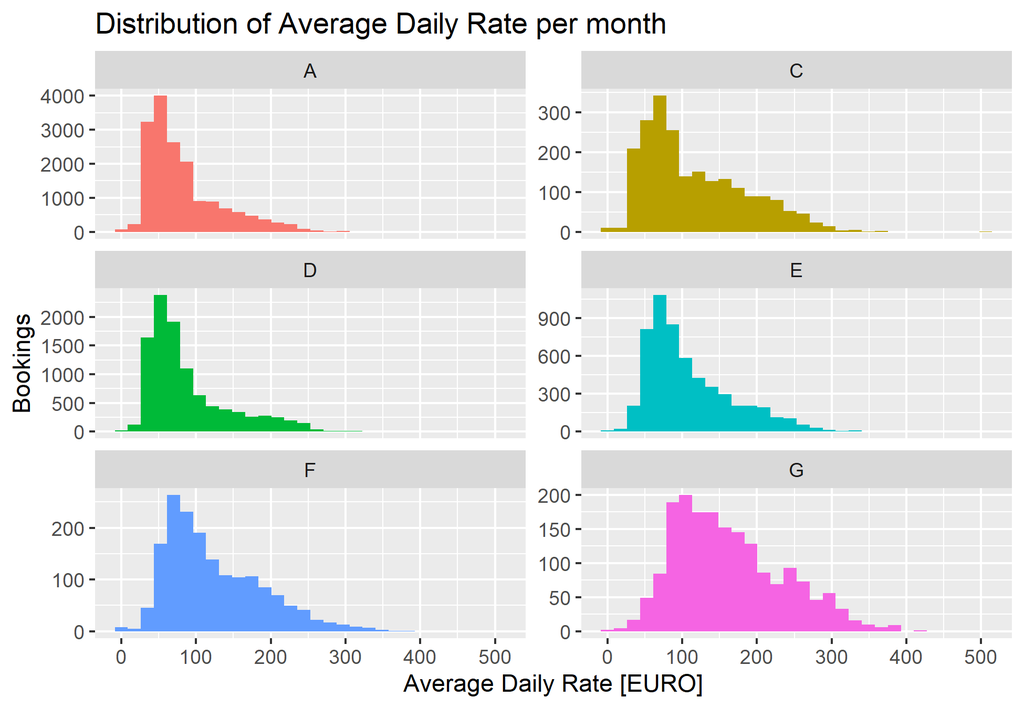

AverageDailyRate_RoomsACDEFG.png

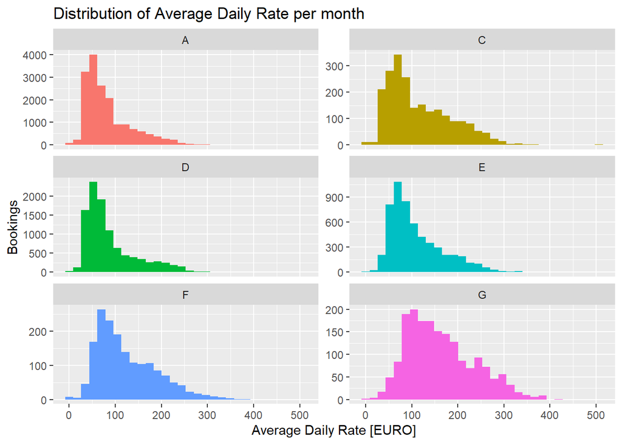

```r
df_bookings %>%
  subset(AssignedRoomType == 'A' | AssignedRoomType == 'C' | AssignedRoomType == 'D' | AssignedRoomType == 'E' | AssignedRoomType == 'F' | AssignedRoomType == 'G') %>%
  ggplot(aes(AverageDailyRate)) +
  geom_histogram(aes(fill = AssignedRoomType)) +
  facet_wrap(~ AssignedRoomType, ncol = 2, scales = 'free_y') +
  theme(legend.position = 'none') +
  labs(title = 'Distribution of Average Daily Rate per month', x = 'Average Daily Rate [EURO]', y = 'Bookings')
```

## Aufgabe (5 Punkte): Vereinfache Facet-Plot des Tagesdurchschnittpreises

Erzeuge für die oben dargestellten Daten nun Boxplots zum Vergleich von Tagesdurchschnittpreisen (‘AverageDailyRate’) nach Zimmertyp (‘AssignedRoomType’) und visualisiere die Gruppengrösse mit Hilfe der Fläche der Box.

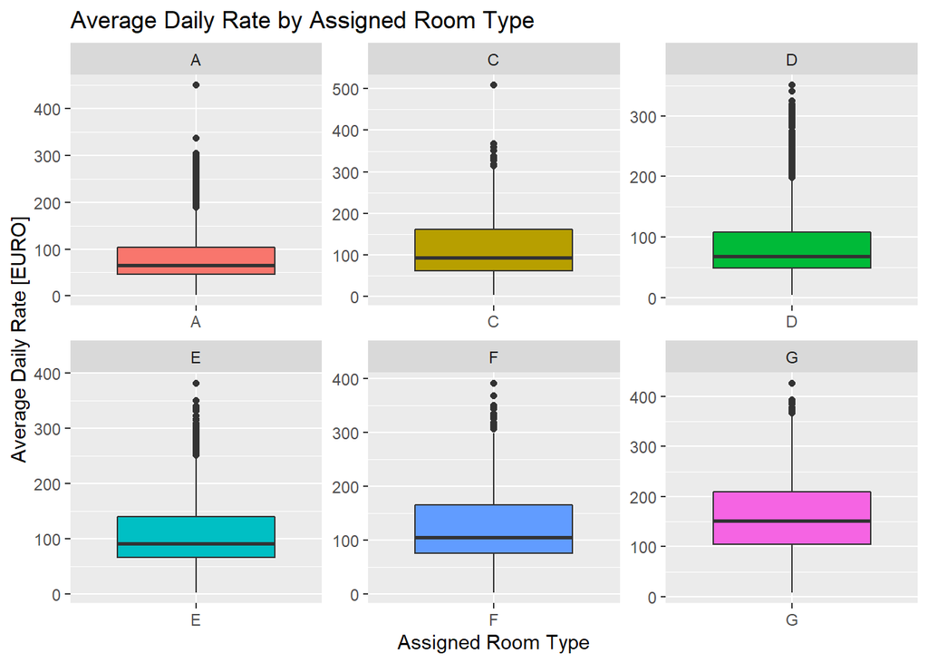

```r
df_bookings %>%
  subset(AssignedRoomType == 'A' | AssignedRoomType == 'C' | AssignedRoomType == 'D' | AssignedRoomType == 'E' | AssignedRoomType == 'F' | AssignedRoomType == 'G') %>%
  ggplot(aes(x = AssignedRoomType, y = AverageDailyRate, fill = AssignedRoomType)) +
  geom_boxplot() +
  facet_wrap(~ AssignedRoomType, ncol = 3, scales = 'free') +
  theme(legend.position = 'none') +
  labs(title = 'Average Daily Rate by Assigned Room Type', x = 'Assigned Room Type', y = 'Average Daily Rate [EURO]')
```

## Aufgabe (5 Punkte): Untersuche und visualisiere Korrelationen

Berechne die Korrelation nach Bravais-Pearson für die Attribute Preis (Attribut ‘Price’) und Anzahl Übernachtungen (Attribut ‘TotalNights’). Erstelle weiter ein Streudiagramm für ‘Price’ vs ‘TotalNights’ und integriere im Untertitel die Information der Anzahl Beobachtungen und der berechneten Korrelation auf drei Nachkommastellen gerundet.

Hinweis: Verwende für deine Implementierung die Funktion `geom_jitter()` mit sinnvoller Wahl der Parameter `alpha` und `shape`.

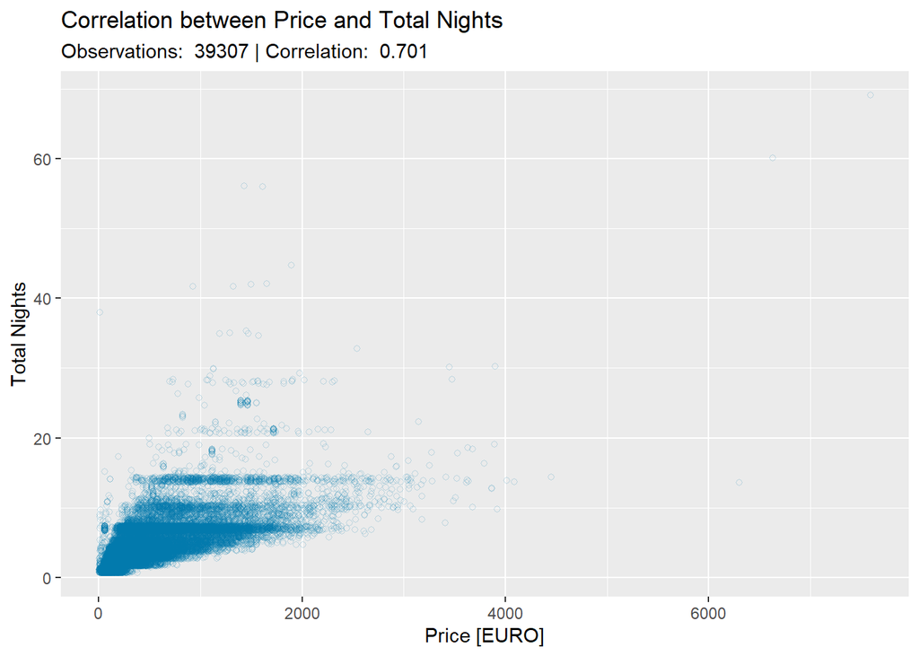

```r
sub <- paste('Observations: ', nrow(df_bookings), '| Correlation: ', round(cor(df_bookings$Price, df_bookings$TotalNights), 3))

df_bookings %>%
  ggplot(aes(Price, TotalNights)) +
  geom_jitter(alpha = 0.2, shape = 1, color = '#0078ab') +
  labs(title = 'Correlation between Price and Total Nights', subtitle = sub, x = 'Price [EURO]', y ='Total Nights')
```

## Aufgabe (10 Punkte): Bereinigung von Ausreissern

Erstelle das obige Streudiagramm für ‘Price’ vs ‘TotalNights’ erneut und schränke die x-Achse und y-Achse so ein, dass Aussreisser am oberen Ende der Skala nicht gezeigt werden. Passe den Untertitel an, indem du erwähnst wieviele Ausreisser nicht gezeigt werden.

Hinweis: Verwende für deine Implementierung die Definition des Boxplots: Ausreißer sind Datenpunkte, die sich ausserhalb der Zäune (‘Whiskers’) des Boxplots befinden. Die Whiskers haben die Länge des 1,5-fachen des Interquartilsbereichs und setzen oberhalb des oberen Quartils und unterhalb des unteren Quartils an.

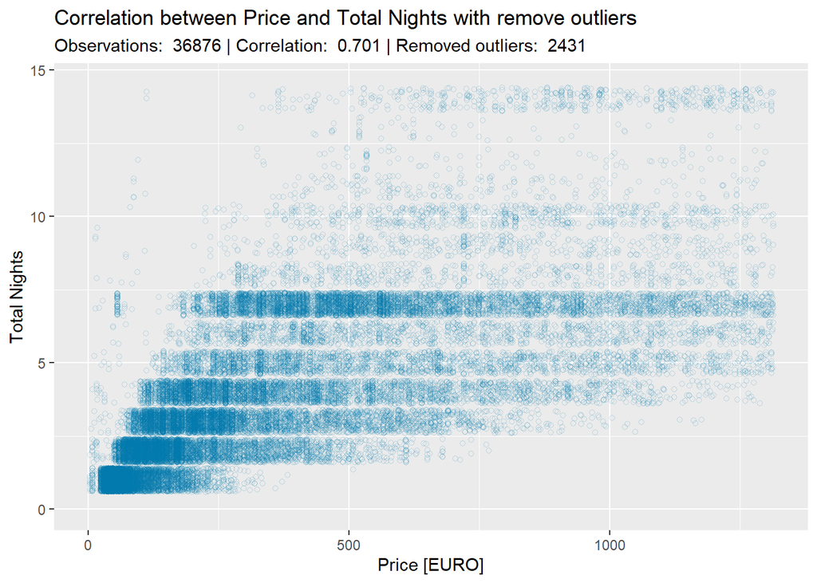

```r
Q_price <- quantile(df_bookings$Price, probs = c(.25, .75), na.rm = FALSE)
iqr_price <- IQR(df_bookings$Price)
upper_range_price <- Q_price[2] + 1.5 * iqr_price
Q_total_nights <- quantile(df_bookings$TotalNights, probs = c(.25, .75), na.rm = FALSE)
iqr_total_nights <- IQR(df_bookings$TotalNights)
upper_range_total_nights <- Q_total_nights[2] + 1.5 * iqr_total_nights

# Count outliers
count_outliers <- df_bookings %>%
  filter(Price >= upper_range_price | TotalNights >= upper_range_total_nights) %>%
  nrow()

sub2 <- paste('Observations: ', nrow(df_bookings) - count_outliers, '| Correlation: ', round(cor(df_bookings$Price, df_bookings$TotalNights), 3), '| Removed outliers: ', count_outliers)

df_bookings %>%
  ggplot(aes(x = Price, y = TotalNights)) +
  geom_jitter(alpha = 0.2, shape = 1, color = '#0078ab') +
  xlim(0, upper_range_price) +
  ylim(0, upper_range_total_nights) +
  labs(title = 'Correlation between Price and Total Nights with remove outliers', subtitle = sub2, x = 'Price [EURO]', y = 'Total Nights')
```

## Aufgabe (10 Punkte): Untersuche den Zeitverlauf der Hotelankünfte

Visualisiere die Anzahl der Hotelbuchungen nach Ankunftsdatum im Zeitverlauf, wobei die stornierten Buchungen nicht zu berücksichtigen sind. Visualisiere den Verlauf über 180 Tage, beginnend am 1. Juni 2016.

Hinweis: Verwende für deine Implementierung `tidyverse` und `lubridate`.

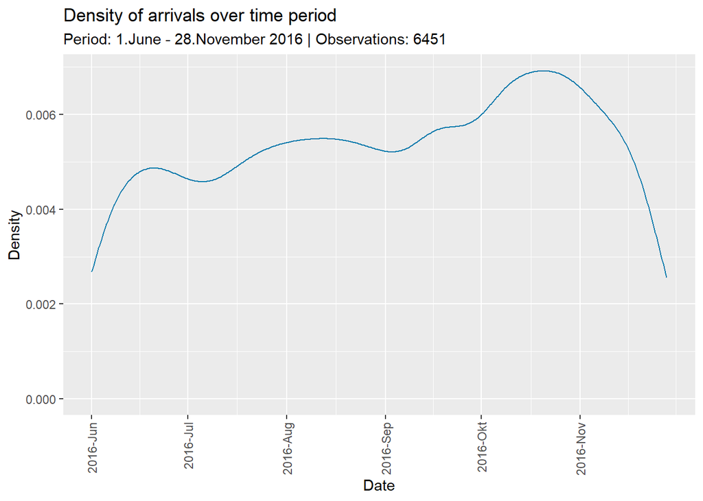

```r
#Count observations
obs_count <- df_bookings %>% filter(BookingCancelled == 'No' & ArrivalDate >= '2016-06-01' & ArrivalDate <= c(as.Date('2016-06-01') + 180)) %>% nrow()

df_bookings %>%
  filter(BookingCancelled == 'No') %>%
  ggplot(aes(x = ArrivalDate)) +
  geom_density(color = '#0078ab') +
  scale_x_date(date_labels = '%Y-%b', breaks = seq(as.Date('2016-06-01'), as.Date('2016-06-01') + 180, 'months'), limits = c(as.Date('2016-06-01'), c(as.Date('2016-06-01') + 180))) +
  theme(axis.text.x = element_text(angle = 90, hjust = 1, vjust = .5)) +
  labs(title = 'Density of arrivals over time period', subtitle = paste('Period: 1.June - 28.November 2016 | Observations:', obs_count), x = 'Date', y = 'Density')
```

## Aufgabe (5 Punkte): Identifiziere Tage mit meisten Buchungen

Identifiziere die fünf Tage mit den meisten Zimmer-Buchungen gemessen am Datum der Ankunft, wobei die stornierten Buchungen nicht zu berücksichtigen sind. Gib zusätzlich die Anzahl Personen an, welche an diesen Tagen eingecheckt haben.

```r
df_bookings %>%
  filter(BookingCancelled == 'No') %>%
  group_by(ArrivalDate) %>%
  summarize(Bookings = n(), 'People_checked_in' = sum(GroupSize)) %>%
  arrange(desc(Bookings)) %>%
  head(5)
```

| ArrivalDate | Bookings | People_checked_in |
| --- | --- | --- |
| 2017-01-16 | 114 | 124 |
| 2015-12-05 | 113 | 238 |
| 2017-03-02 | 104 | 179 |
| 2015-12-30 | 99 | 197 |
| 2017-05-25 | 99 | 197 |

## Aufgabe (10 Punkte): Untersuche den Zeitverlauf des mittleren Tagesdurchschnittspreise der Buchungen

Berechne für 2016 die zeitliche Entwicklung des Tagesdurchschnittspreises (‘AverageDailyRate’) aller Buchungen pro Woche. Visualisiere den Median sowie das 25%-Perzentil und 75%-Perzentil, um die Streuung des Tagesdurchschnittspreises zu illustrieren.

Bestimme und markiere dann visuell die Kalenderwoche mit dem höchsten Tagesdurchschnittspreis mit Hilfe einer vertikalen roten Linie.

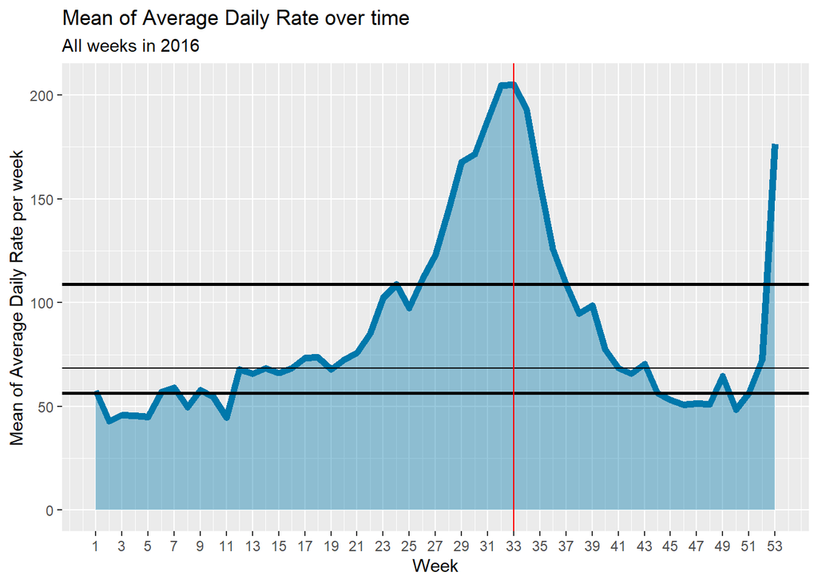

```r
df_bookings %>%
  filter(ArrivalDate >= '2016-01-01' & ArrivalDate <= '2016-12-31') %>%
  group_by(week = week(ArrivalDate)) %>%
  summarise(mean_week = mean(AverageDailyRate)) %>%
  ggplot(aes(x = week, y = mean_week)) +
  geom_area(fill = '#0078ab', alpha = 0.4) +
  geom_line(color = '#0078ab', size = 2) +
  geom_hline(aes(yintercept = quantile(mean_week)[2]), color = 'black', size = 1) +
  geom_hline(aes(yintercept = quantile(mean_week)[4]), color = 'black', size = 1) +
  geom_hline(aes(yintercept = median(mean_week))) +
  geom_vline(aes(xintercept = week[mean_week == max(mean_week)]), color = 'red') +
  scale_x_continuous(breaks = seq(1, 53, 2)) +
  labs(title = 'Mean of Average Daily Rate over time', subtitle = 'All weeks in 2016', x = 'Week', y = 'Mean of Average Daily Rate per week')
```

# Eigene Analysen

## Aufgabe (20 Punkte): Exploriere den Datensatz weiter

Untersuche weitere, noch nicht beleuchtete Zusammenhänge in den Daten und dokumentiere (a) deine Hypothese, (b) die gefundenen Zusammenhängen präzise in Worten.

### Topic 1: Seasonal impact on room pricing

#### Hypothesis:

In the last plot, we observed, that in the year 2016 the AverageDailyRate had a peak in the Summer season. We want to find out, if the season has a direct impact on the room prices.

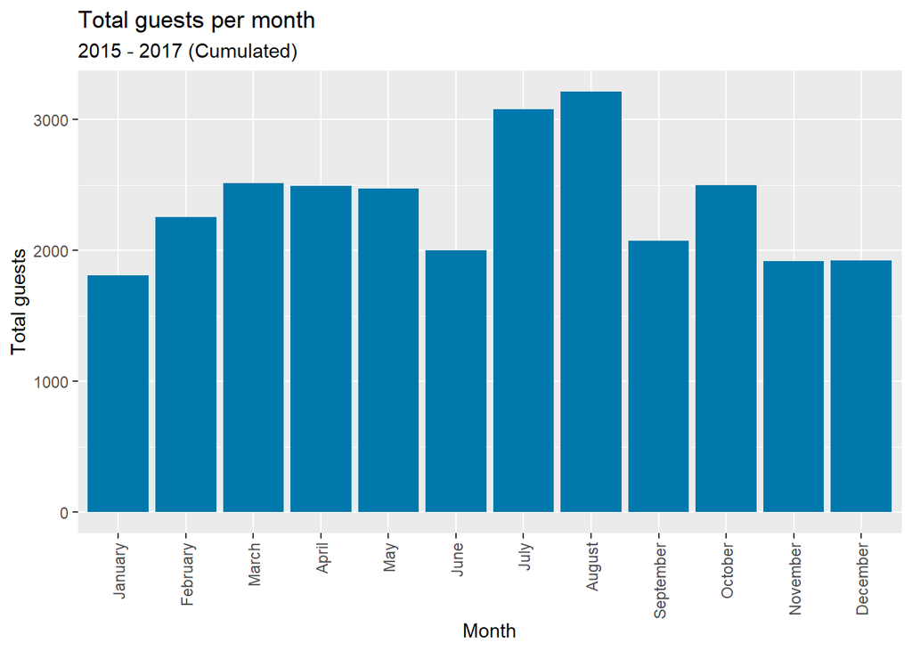

```r
df_bookings %>%
  filter(BookingCancelled == 'No') %>%
  group_by(ArrivalDateMonth) %>%
  summarise(monthly_visitors = n()) %>%
  ggplot(aes(x = ArrivalDateMonth, y = monthly_visitors)) +
  geom_bar(stat = 'identity', fill = '#0078ab') +
  theme(axis.text.x = element_text(angle = 90, hjust = 1, vjust = .5)) +
  labs(title = 'Total guests per month', subtitle = '2015 - 2017 (Cumulated)', x = 'Month', y = 'Total guests')
```

#### Observations:

To find out if the season has an impact on prices, we first had to look at demand. In the upper plot we can see that most guests visit the hotel in summer. We can see that the season has a direct impact on the demand.

[output not shown]

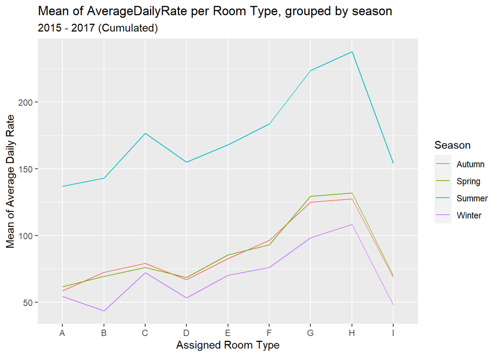

```r
df_bookings %>%
  filter(AssignedRoomType != 'L') %>%
  group_by(AssignedRoomType, AverageDailyRate) %>%
  summarise(Season = case_when(ArrivalDateMonth == 'January' | ArrivalDateMonth == 'February' | ArrivalDateMonth == 'December' ~ 'Winter', ArrivalDateMonth == 'March' | ArrivalDateMonth == 'April' | ArrivalDateMonth == 'May' ~ 'Spring', ArrivalDateMonth == 'June' | ArrivalDateMonth == 'July' | ArrivalDateMonth == 'August' ~ 'Summer', ArrivalDateMonth == 'September' | ArrivalDateMonth == 'October' | ArrivalDateMonth == 'November' ~ 'Autumn')) %>%
  group_by(Season, AssignedRoomType) %>%
  summarise(AverageDailyRate = mean(AverageDailyRate)) %>%
  ggplot(aes(x = AssignedRoomType, y = AverageDailyRate, color = Season, group = Season)) +
  geom_line() +
  labs(title = 'Mean of AverageDailyRate per Room Type, grouped by season', subtitle = '2015 - 2017 (Cumulated)', x = 'Assigned Room Type', y = 'Mean of Average Daily Rate')
```

#### Observations:

In the upper plot we see that the price trends per RoomType are similar across all seasons. The main difference is that the prices in the summer experience a uniform increase. The winter experiences a slight price decrease. The prices here also follow the same pattern.

#### Conclusion:

The plots show that season has a direct impact on room rates. Our hypothesis is thus confirmed.

### Topic 2: Distribution of total revenue

#### Hypothesis:

We have seen that prices vary seasonally. Now we would like to find out if the season has an influence on the revenue.

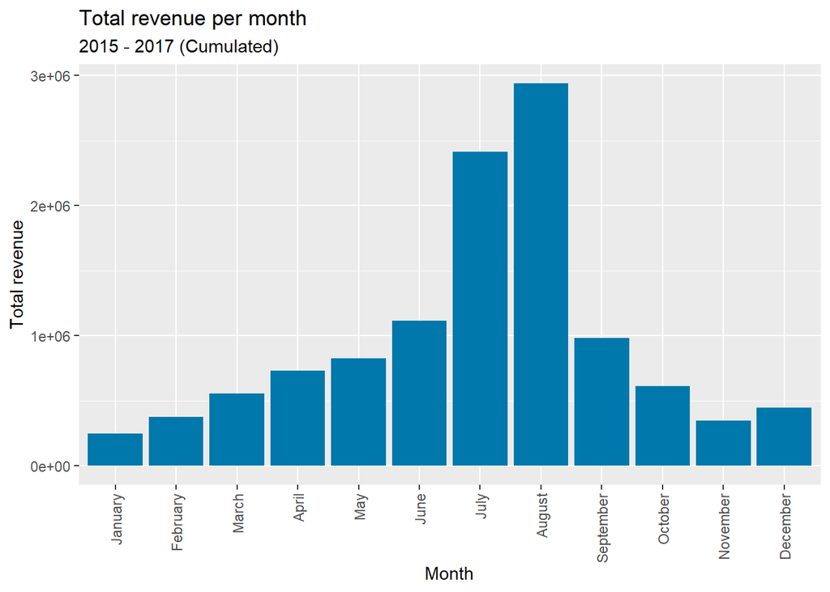

```r
df_bookings %>%
  filter(BookingCancelled == 'No') %>%
  group_by(ArrivalDateMonth) %>%
  summarise(monthly_revenue = sum(Price)) %>%
  ggplot(aes(x = ArrivalDateMonth, y = monthly_revenue)) +
  geom_bar(stat = 'identity', fill = '#0078ab') +
  theme(axis.text.x = element_text(angle = 90, hjust = 1, vjust = .5)) +
  labs(title = 'Total revenue per month', subtitle = '2015 - 2017 (Cumulated)', x = 'Month', y = 'Total revenue')
```

#### Observations:

The plot displays, that the summer months are the most profitable for the hotel. By further investigating, we can see in graph 2 that the summer months July and August also have the most visitors. This also seem to correlate with Average Daily Rate in the year 2016. Because the demand for rooms is higher in the summer months, the hotel can charge the willing customer more and the revenue skyrockets.

#### Conclusion:

As we found out in the previous hypothesis, season has an impact on prices. We could observe this here as well, since summer is the most profitable season.

### Topic 3: Correlations between IsRepeatedGuest and BookingCancelled / IsRepeatedGuest and PreviousBookingsNotCanceled

#### Hypothesis:

1. We think that bookings from recurring customers are cancelled less than those from non-recurring customers.
2. We think that recurring customers will have less cancelled bookings from the past than non-recurring customers.

[output not shown]

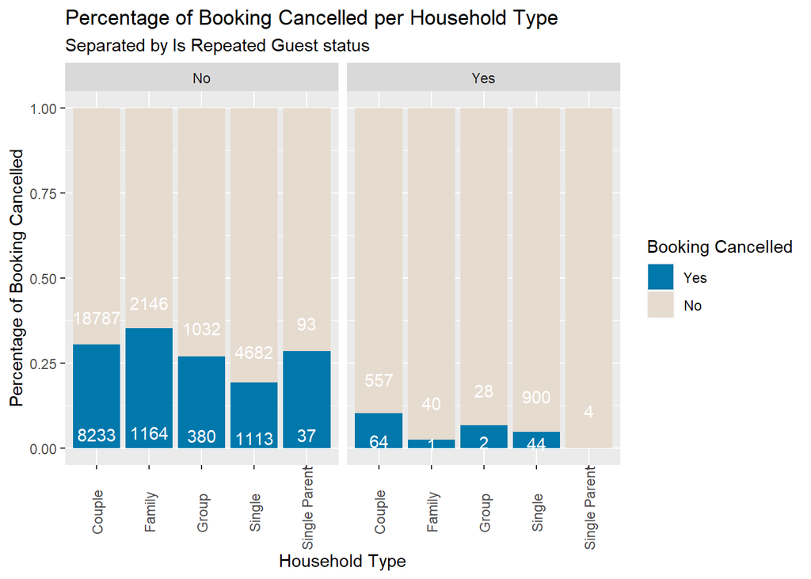

```r
df_bookings %>%
  group_by(HouseholdType,BookingCancelled,IsRepeatedGuest) %>%
  summarise(Freq= n()) %>%
  ggplot(aes(fill=BookingCancelled, y=Freq, x=HouseholdType)) +
  geom_bar(position = 'fill', stat='identity') +
  scale_fill_manual('Booking Cancelled', values = c('Yes' = '#0078ab', 'No' = '#e6dbcf')) +
  facet_wrap(~IsRepeatedGuest) +
  theme(axis.text.x = element_text(angle = 90, hjust = 0.4, vjust = .5,margin = margin(-1))) +
  geom_text(aes(label = Freq),
            position = position_fill(0.1),
            color='white',vjust = 0.25,hjust = 0.5) +
  labs(title = 'Percentage of Booking Cancelled per Household Type', subtitle = 'Separated by Is Repeated Guest status', x = 'Household Type', y = 'Percentage of Booking Cancelled')
```

#### Observations:

We see that the majority of bookings are not cancelled. However, we also see that returning customers on average cancel less bookings than non-recurring customers.

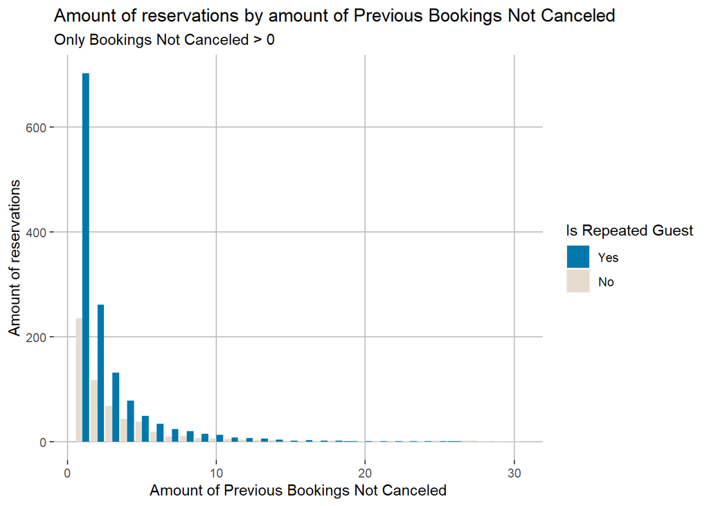

```r
df_bookings %>%
  filter(PreviousBookingsNotCanceled > 0) %>%
  group_by(PreviousBookingsNotCanceled, IsRepeatedGuest) %>%
  summarise(Freq= n()) %>%
  ggplot(aes(fill=IsRepeatedGuest, y=Freq, x=PreviousBookingsNotCanceled)) +
  geom_bar(position = 'dodge', stat='identity') +
  scale_fill_manual('Is Repeated Guest', values = c('Yes' = '#0078ab', 'No' = '#e6dbcf')) +
  theme(panel.background = element_rect(fill = 'white'),
panel.grid.major = element_line(color = 'grey')) +
  labs(title = 'Amount of reservations by amount of Previous Bookings Not Canceled', subtitle = 'Only Bookings Not Canceled > 0', x = 'Amount of Previous Bookings Not Canceled', y = 'Amount of reservations')
```

#### Observations:

Here it can be seen that recurring customers dominate for all cases with sufficient data. This means that in all these cases the recurring customers dominate and therefore have more bookings that are not cancelled than customers who are not recurring.

#### Conclusion:

With the help of the graphs, we were able to establish a connection between the repeat status of the guests and the cancellation of their reservations. This applies to the ‘BookingCancelled’ and ‘PreviousBookingsNotCancelled’.

### Topic 4: Analysis of the correlations of: DaysInWaitingList and the AssignedRoomType / DaysInWaitingList and ArrivalDateMonth.

#### Hypothesis:

1. If we look at the waiting times for the different room categories, we should see trends. These trends could also be reflected in analyses/observations already made.
2. By comparing the DaysInWaitingList with the months, we hope to be able to observe seasonal differences here as in other analyses.

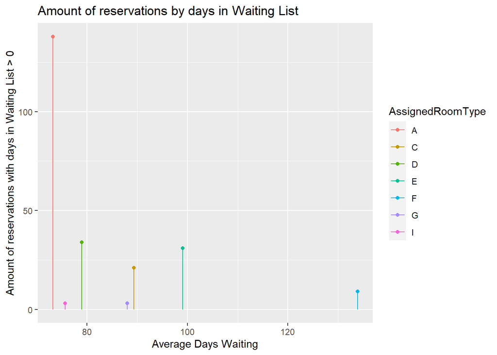

```r
df_bookings %>%
  filter(DaysInWaitingList > 0) %>%
  group_by(AssignedRoomType) %>%
  summarise(AverageDaysWaiting = mean(DaysInWaitingList), n = n()) %>%
  ggplot(aes(y = n, x = AverageDaysWaiting, color = AssignedRoomType)) +
  geom_point(stat = 'identity') +
  geom_segment( aes(xend=AverageDaysWaiting, y=0, yend=n)) +
  labs(title = 'Amount of reservations by days in Waiting List', x = 'Average Days Waiting', y = 'Amount of reservations with days in Waiting List > 0')
```

#### Observations:

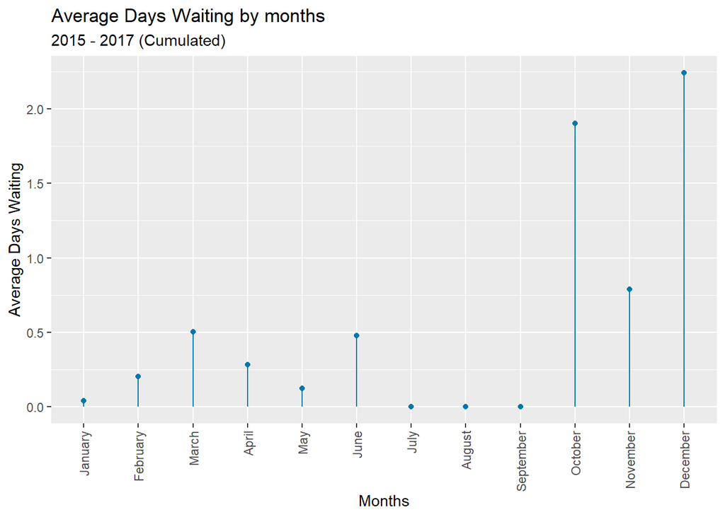

```r
df_bookings %>%
  group_by( ArrivalDateMonth) %>%
  summarise(AverageDaysWaiting = mean(DaysInWaitingList), n = n()) %>%
  ggplot(aes(y = AverageDaysWaiting, x = ArrivalDateMonth)) +
  geom_point(stat = 'identity', color = '#0078ab') +
  geom_segment( aes(xend=ArrivalDateMonth, y=0, yend=AverageDaysWaiting), color = '#0078ab')  +
  theme(axis.text.x = element_text(angle = 90, hjust = 1, vjust = .5)) +
  labs(title = 'Average Days Waiting by months', subtitle = '2015 - 2017 (Cumulated)', x = 'Months', y = 'Average Days Waiting')
```

#### Conclusion:

We could see a correlation between AssignedRoomTypes and AverageDaysWaiting, which is also consistent with other analyses. However, we were not able to find seasonal differences that coincide with other observations. In concrete terms, this means that the waiting list days are not related to the turnover or visitor numbers and that other influencing factors may be important here. We can imagine that a hotel that makes its biggest turnover in the summer, reduces its capacity in the mid-season period and therefore has longer waiting times.